# Analysis of Korkola et al. RPPA data

Evert Bosdriesz

2021-07-19

# Summary/Background

## Aim

Here we analyze RPPA data from Korkola et al., PLOS ONE, 2015. The main aim is to see how strong the signal of targeted inhibition is in cells that are not starved and restimulated. This should inform the decision for the MCF10A WT/PI3Kmut perturbation experiments we plan to do.

## Experimental setup

# Data analysis

## Data import

Get and clean the data.

```r
df <- readxl::read_xlsx(here("data/Korkola-etal-rppa/journal.pone.0133219.s001.XLSX"), skip = 7)

df <- df %>%
  separate(`Sample Name`, into = c("cell_line", "treatment", "time"), sep = "\\)|_") %>%
  mutate(
    cell_line = str_replace_all(cell_line, "\\s|\\([0-9]*", ""),
    time = as.numeric(str_trim(str_replace(str_replace(time, "hr", ""), "1/2", "0.5"))),
    treatment = factor(treatment, levels = c("DMSO", "Lapatinib", "AKTi", "Lap+AKTi"))
    )

head(df)
```

| Sample # | cell_line | treatment | time | 14-3-3--Beta(V) | 14-3-3-Epsillon | 14-3-3-Sigma(mouse) | 14-3-3-Zeta(C) | 4EBP1(V) | 4EBP1_pS65(V) | 4EBP1_pT37(V) | 4EBP1_pT70 | a-Tubulin | a_b_Crystallin | ACC1(C) | AIB1(mouse) | AKT(V) | AKT_pS473(V) | AKT_pT308(V) | AMPK_pT172(V) | AMPKa(C) | Annexin | AR(V) | ATM | ATM_pS1981(Mouse) | b-Catenin(V) | b-RAF(mouse)(C) | BAD_pS112(C) | BAK(C) | BAX(C) | … |
| --- | --- | --- | --- | --- | --- | --- | --- | --- | --- | --- | --- | --- | --- | --- | --- | --- | --- | --- | --- | --- | --- | --- | --- | --- | --- | --- | --- | --- | --- | --- |
| 1 | AU565 | DMSO | 0.5 | -0.1015368888 | -0.28188602 | -0.5006041 | -0.6139440 | -0.55676140 | -0.2000823 | 0.25866812 | -0.3808127 | -0.91434793 | -0.46737119 | 0.04735860 | 0.6014876 | -0.07330370 | -0.5769371 | -0.9950184 | -0.5634330 | 0.1195332916 | -1.0327574 | -0.3760063 | 0.36199211 | -0.19883971 | -2.486219 | 0.3611583 | 0.241053457 | -0.0503633 | -0.002744486 | … |
| 2 | AU565 | Lapatinib | 0.5 | 0.0003500956 | -0.24613362 | -0.4391566 | -0.7108931 | -0.06361498 | -0.2166633 | 0.09492549 | -0.2374382 | -0.36039994 | -0.02665859 | 0.06746676 | 0.5061584 | -0.04677313 | -1.3032229 | -1.5411069 | -0.4686737 | 0.2016460796 | -0.8756641 | -0.1811061 | 0.03845940 | -0.26561637 | -2.375631 | 0.3252164 | 0.203313944 | 0.1000831 | -0.026615368 | … |
| 3 | AU565 | AKTi | 0.5 | -0.1977824467 | -0.33040392 | -0.5231146 | -0.5591582 | -0.42749573 | -0.1149331 | 0.18908308 | -0.3453572 | 0.11659367 | 0.35064036 | -0.08640647 | 0.5250784 | -0.18692165 | 0.2062962 | 0.4084784 | -0.7827600 | 0.0038438996 | -0.9399429 | -0.5737497 | 0.34080792 | -0.14325123 | -2.619673 | 0.5728710 | -0.015720612 | -0.1349726 | -0.172639022 | … |
| 4 | AU565 | Lap+AKTi | 0.5 | 0.0106832939 | -0.22854793 | -0.5888494 | -0.6031951 | -0.09087445 | -0.2690774 | 0.02039620 | -0.2347983 | -0.17074936 | 0.05648377 | 0.01955805 | 0.4545748 | -0.17028218 | -0.3057812 | -0.1698409 | -0.5216716 | 0.1501789678 | -1.1071797 | -0.3510610 | 0.18460387 | 0.11382189 | -2.394195 | 0.3257154 | 0.038117438 | 0.2329483 | -0.052035729 | … |
| 5 | AU565 | DMSO | 1.0 | -0.1145310404 | -0.05710998 | -0.5121937 | -0.5569440 | -0.37052962 | -0.2671153 | 0.20812468 | -0.3755537 | -0.03728654 | 0.42458983 | -0.10738869 | 0.6410411 | -0.06208881 | -0.8510757 | -1.2553698 | -1.0158545 | 0.0007859893 | -0.9251488 | -0.5332169 | 0.14336271 | -0.04572788 | -2.564709 | 0.4574290 | -0.028393508 | -0.1176074 | -0.203800971 | … |
| 6 | AU565 | Lapatinib | 1.0 | 0.1023386050 | -0.10471325 | -0.4190114 | -0.5966301 | -0.07057421 | -0.3153459 | -0.21729625 | -0.1375185 | -0.19726593 | 0.29916139 | -0.06184890 | 0.4587588 | -0.15520647 | -2.0845828 | -1.9661202 | -0.6592262 | 0.1207973992 | -0.5828972 | -0.2738717 | -0.03173025 | -0.13999281 | -2.266845 | 0.3126080 | 0.007535661 | 0.1016012 | -0.161857804 | … |

We restrict analysis to epitopes that are part of the Prot-at-once assay we will use.

```r
df_pao <- df %>%
  select(cell_line, treatment, time, matches("AKT_pS473|MEK1_2_pS217|GSK3a_b_pS21|p70S6K_pT389|S6_pS235")) %>%
  gather(epitope, expression, -cell_line, -treatment, -time)
```

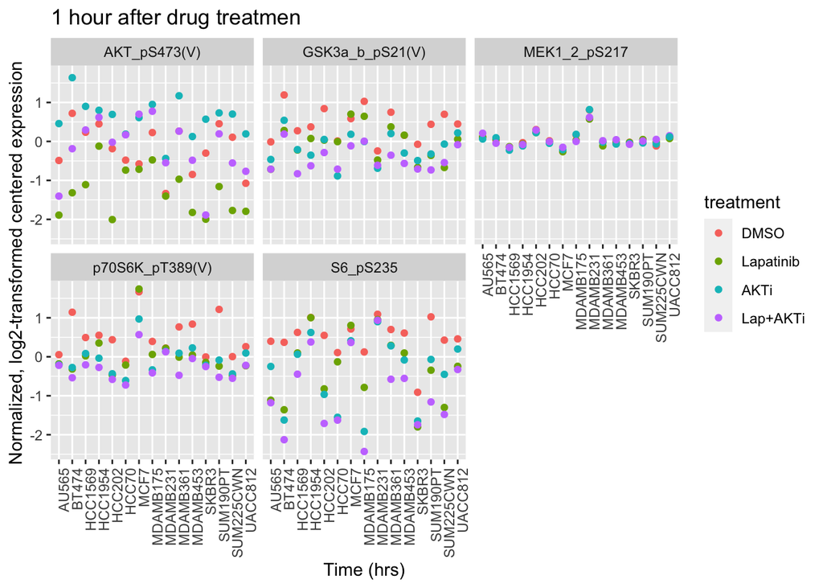

```r
ggplot(filter(df_pao, time == "2"), aes(x = cell_line, y = expression, fill = treatment, color = treatment)) +
  geom_point() +
  labs(x = "Time (hrs)", y = "Normalized, log2-transformed centered expression",
       title = "1 hour after drug treatmen") +
  facet_wrap(~epitope) +
  theme(axis.text.x = element_text(angle = 90, hjust = 1))
```

Of note:

- AKT pS473 shows clear effect of feedback activation upon AKT inhibition in most/all cell lines.

For completeness, also the full time course data.

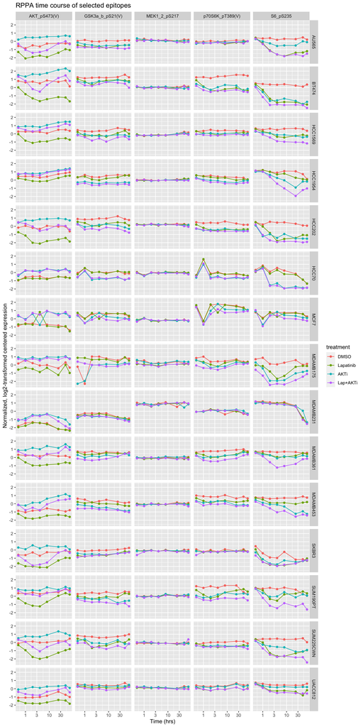

```r
ggplot(df_pao, aes(x = time, y = expression, color = treatment)) +
  geom_line() +
  geom_point() +
  scale_x_log10() +
  labs(x = "Time (hrs)", y = "Normalized, log2-transformed centered expression",
       title = "RPPA time course of selected epitopes") +
  facet_grid(cell_line~epitope)
```

```r
  #my_theme
```

Of note:

- For selection of the timepoint: AKT shows little dynamics after 1 hour.
- pS6 continues to decrease after 1 hour, but in most cell lines where it decreases, clear onset present after 1 hour.
- Most other epitopes remain flat. This is not very surprising since e.g. the MAPK pathway is not perturbed.

We also plot the dymanics of AKT only.

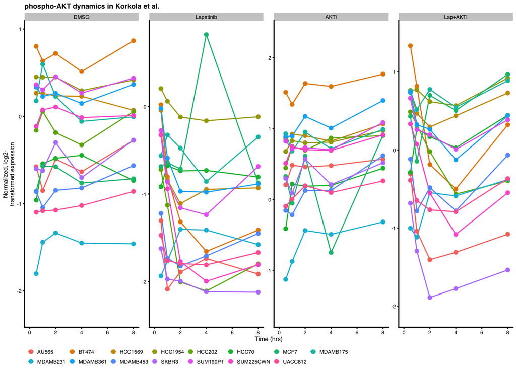

```r
ggplot(
  filter(df_pao, epitope == "AKT_pS473(V)"),
  aes(x = time, y = expression, color = cell_line)) +
  geom_line() +
  geom_point() +
  facet_wrap(~treatment, scales = "free_y", nrow=1) +
  xlim(c(0, 8)) +
  labs(x = "Time (hrs)", y = "Normalized, log2-\ntransformed expression",
       title = "phospho-AKT dynamics in Korkola et al. ") +
  cowplot::theme_cowplot(font_family = "Helvetica", font_size = 6) +
  theme(legend.position = "bottom", legend.title = element_blank()) +
  guides(color=guide_legend(nrow=2,byrow=TRUE))
```

```r
ggsave(here("figures", "Misc", "Korkula-time-course.pdf"),  height = 1.5, width = 6)
```

[output not shown]